# 01 컨볼루션 신경망(Convolution Neural Network, CNN)

## 주요 레이어

### Conv2D

- `tensorflow.keras.layers.Conv2D`
- `tf.nn.conv2d`

```python
import tensorflow as tf
from tensorflow.keras.layers import Conv2D

import matplotlib.pyplot as plt
plt.style.use('seaborn-white')

import numpy as np
from sklearn.datasets import load_sample_image
```

```python
china = load_sample_image('china.jpg') / 255
china.dtype, china.shape
```

```
(dtype('float64'), (427, 640, 3))
```

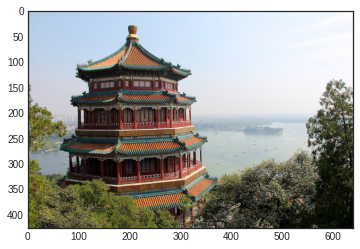

```python
plt.imshow(china)
plt.show()
```

```python
flower = load_sample_image('flower.jpg') / 255
flower.dtype, flower.shape
```

```
(dtype('float64'), (427, 640, 3))
```

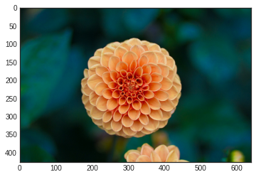

```python
plt.imshow(flower)
plt.show()
```

```python
images = np.array([china, flower])
batch_size, height, width, channels = images.shape
images.shape # 427 X 640 X 3의 사진이 2장
# 배치 크기, 높이, 넓이, 색상차원
```

```
(2, 427, 640, 3)
```

```python
filters = np.zeros(shape = (7, 7, channels, 2), dtype = np.float32)
filters[:, 3, :, 0] = 1 # 수직
filters[3, :, :, 1] = 1 # 수평

print(filters.shape)
```

```
(7, 7, 3, 2)
```

```
(2, 427, 640, 2)
```

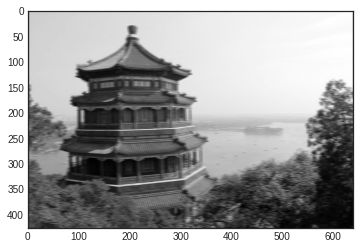

```python
outputs = tf.nn.conv2d(images, filters, strides = 1, padding = 'SAME')
print(outputs.shape)
plt.imshow(outputs[0, :, :, 1], cmap = 'gray')
plt.show()
```

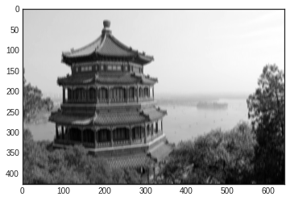

```python
plt.imshow(outputs[0, :, :, 0], cmap = 'gray')
plt.show()
```

```python
conv = Conv2D(filters = 32, kernel_size = 3, strides = 1,
              padding = 'same', activation = 'relu')
```

### MaxPool2D

- 텐서플로 저수준 딥러닝 API
  - `tf.nn.max_pool`
  - 사용자가 사이즈를 맞춰줘야함
  - 케라스의 모델의 층으로 사용하고 싶으면 Lambda층으로 감싸줘야함
- 케라스 고수준 API
  - `keras.layers.MaxPool2D`

```python
import tensorflow as tf
from tensorflow.keras.layers import MaxPool2D, Lambda
```

```python
output = tf.nn.max_pool(images,
                        ksize = (1, 1, 1, 3),
                        strides = (1, 1, 1, 3),
                        padding = 'VALID')
```

```python
output_keras = Lambda(
  lambda X: tf.nn.max_pool(X, ksize = (1, 1, 1, 3), strides = (1, 1, 1, 3), padding = "VALID")
)
```

```python
max_pool = MaxPool2D(pool_size = 2) # 풀링 사이즈 2X2
```

```python
flower = load_sample_image('flower.jpg') / 255
print(flower.dtype)
print(flower.shape)
```

```
float64
(427, 640, 3)
```

```python
flower = np.expand_dims(flower, axis = 0)
flower.shape
```

```
(1, 427, 640, 3)
```

```python
output = Conv2D(filters = 32, kernel_size = 3, strides = 1, padding = 'same', activation = 'relu')(flower)
output = MaxPool2D(pool_size = 2)(output)

output.shape
```

```
TensorShape([1, 213, 320, 32])
```

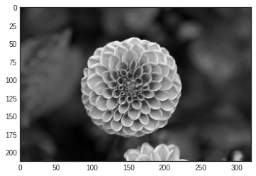

```python
plt.imshow(output[0, :, :, 4], cmap = 'gray')
plt.show()
```

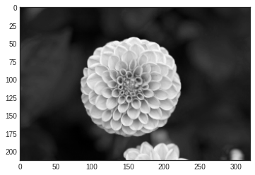

```python
plt.imshow(output[0, :, :, 8], cmap = 'gray')
plt.show()
```

### AvgPool2D

- 텐서플로 저수준 딥러닝 API
  - `tf.nn.avg_pool`
- 케라스 고수준 API
  - `keras.layers.AvgPool2D`

```python
from tensorflow.keras.layers import AvgPool2D
```

```python
flower.shape
```

```
(1, 427, 640, 3)
```

```python
output = Conv2D(filters = 32, kernel_size = 3, strides = 1, padding = 'same', activation = 'relu')(flower)
output = AvgPool2D(pool_size = 2)(output)

output.shape
```

```
TensorShape([1, 213, 320, 32])
```

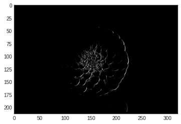

```python
plt.imshow(output[0, :, :, 2], cmap = 'gray')
```

### GlobalAvgPool2D (전역 평균 풀링 층)

- `keras.layers.GlobalAvgPool2D()`
- 특징 맵 각각의 평균값을 출력하는 것이므로, 특성맵에 있는 대부분의 정보를 잃음
- 출력층에는 유용할 수 있음

```python
from tensorflow.keras.layers import GlobalAvgPool2D
```

```python
flower.shape
```

```
(1, 427, 640, 3)
```

```python
output = Conv2D(filters = 32, kernel_size = 3, strides = 1, padding = 'same', activation = 'relu')(flower)
output = GlobalAvgPool2D()(output)

output.shape
```

```
TensorShape([1, 32])
```

# 02 케라스 CNN Fashion MNIST

#### module import

```python
%load_ext tensorboard
```

```python
import datetime
import numpy as np
import tensorflow as tf
import matplotlib.pyplot as plt
plt.style.use('seaborn-white')

from tensorflow.keras import Model
from tensorflow.keras.models import Sequential
from tensorflow.keras.utils import to_categorical
from tensorflow.keras.datasets.fashion_mnist import load_data
from tensorflow.keras.layers import Dense, Flatten, Conv2D, MaxPool2D, Dropout, Input
```

### 데이터 로드 및 전처리

```python
(x_train, y_train), (x_test, y_test) = load_data()

x_train = x_train[..., np.newaxis]
x_test = x_test[..., np.newaxis]

x_train = x_train / 255
x_est = x_test / 255

x_train.shape, y_train.shape, x_test.shape, y_test.shape
```

```
((60000, 28, 28, 1), (60000,), (10000, 28, 28, 1), (10000,))
```

```python
class_names = ['T-shirt/top', 'Trouser', 'Pullover', 'Dress', 'Coat',
               'Sandal', 'Shirt', 'Sneaker', 'Bag', 'Ankle boot']
```

### 모델 구성 및 컴파일

- 임의의 모델

```python
def build_model():
  model = Sequential()

  input = Input(shape = (28, 28, 1))
  output = Conv2D(filters = 32, kernel_size = (3, 3))(input)
  output = Conv2D(filters = 64, kernel_size = (3, 3))(output)
  output = Conv2D(filters = 64, kernel_size = (3, 3))(output)
  output = Flatten()(output)
  output = Dense(128, activation = 'relu')(output)
  output = Dense(64, activation = 'relu')(output)
  output = Dense(10, activation = 'softmax')(output)

  model = Model(inputs = [input], outputs = output)

  model.compile(optimizer = 'adam',
                loss = 'sparse_categorical_crossentropy',
                metrics = ['accuracy'])

  return model

model_1 = build_model()
model_1.summary()
```

```
Model: "model_5"
_________________________________________________________________
 Layer (type)                Output Shape              Param #
=================================================================
 input_6 (InputLayer)        [(None, 28, 28, 1)]       0

 conv2d_15 (Conv2D)          (None, 26, 26, 32)        320

 conv2d_16 (Conv2D)          (None, 24, 24, 64)        18496

 conv2d_17 (Conv2D)          (None, 22, 22, 64)        36928

 flatten_5 (Flatten)         (None, 30976)             0

 dense_15 (Dense)            (None, 128)               3965056

 dense_16 (Dense)            (None, 64)                8256

 dense_17 (Dense)            (None, 10)                650

=================================================================
Total params: 4,029,706
Trainable params: 4,029,706
Non-trainable params: 0
_________________________________________________________________
```

### 모델 학습

- 런타임 GPU로 설정

```python
hist_1 = model_1.fit(x_train, y_train,
                   epochs = 25,
                   validation_split = 0.3,
                   batch_size = 128, verbose = False)
```

### 학습 결과 시각화

```python
history_1_dict = hist_1.history
loss = history_1_dict['loss']
val_loss = history_1_dict['val_loss']
accuracy = history_1_dict['accuracy']
val_accuracy = history_1_dict['val_accuracy']
epochs = range(1, len(loss) + 1)
```

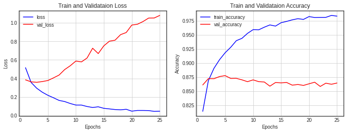

```python
plt.figure(figsize = (12 , 4))

ax1 = plt.subplot(1, 2, 1)
ax1.plot(epochs, loss, color = 'blue', label = 'loss')
ax1.plot(epochs, val_loss, color = 'red', label = 'val_loss')
ax1.set_title('Train and Validataion Loss')
ax1.set_xlabel('Epochs')
ax1.set_ylabel('Loss')
ax1.grid()
ax1.legend()

ax2 = plt.subplot(1, 2, 2)
ax2.plot(epochs, accuracy, color = 'blue', label = 'train_accuracy')
ax2.plot(epochs, val_accuracy, color = 'red', label = 'val_accuracy')
ax2.set_title('Train and Validataion Accuracy')
ax2.set_xlabel('Epochs')
ax2.set_ylabel('Accuracy')
ax2.grid()
ax2.legend()
plt.show()
```

### 모델 평가

```python
model_1.evaluate(x_test, y_test)
```

```
[71.37063598632812, 0.8119999766349792]
```

### 모델 재구성

- 학습 파라미터의 수 비교

```python
def build_model2():
  model = Sequential()

  input = Input(shape = (28, 28, 1))
  output = Conv2D(filters = 32, kernel_size = (3, 3))(input)
  output = MaxPool2D(strides = (2,2))(output)
  output = Conv2D(filters = 64, kernel_size = (3, 3))(output)
  output = MaxPool2D(strides = (2,2))(output)
  output = Conv2D(filters = 64, kernel_size = (3, 3))(output)
  output = MaxPool2D(strides = (2,2))(output)
  output = Flatten()(output)
  output = Dense(128, activation = 'relu')(output)
  output = Dropout(0.5)(output)
  output = Dense(64, activation = 'relu')(output)
  output = Dropout(0.5)(output)
  output = Dense(10, activation = 'softmax')(output)

  model = Model(inputs = [input], outputs = output)

  model.compile(optimizer = 'adam',
                loss = 'sparse_categorical_crossentropy',
                metrics = ['accuracy'])

  return model

model_2 = build_model2()
model_2.summary()
```

```
Model: "model_7"
_________________________________________________________________
 Layer (type)                Output Shape              Param #
=================================================================
 input_8 (InputLayer)        [(None, 28, 28, 1)]       0

 conv2d_21 (Conv2D)          (None, 26, 26, 32)        320

 max_pooling2d (MaxPooling2D  (None, 13, 13, 32)       0
 )

 conv2d_22 (Conv2D)          (None, 11, 11, 64)        18496

 max_pooling2d_1 (MaxPooling  (None, 5, 5, 64)         0
 2D)

 conv2d_23 (Conv2D)          (None, 3, 3, 64)          36928

 max_pooling2d_2 (MaxPooling  (None, 1, 1, 64)         0
 2D)

 flatten_7 (Flatten)         (None, 64)                0

 dense_21 (Dense)            (None, 128)               8320

 dropout (Dropout)           (None, 128)               0

 dense_22 (Dense)            (None, 64)                8256

 dropout_1 (Dropout)         (None, 64)                0

 dense_23 (Dense)            (None, 10)                650

=================================================================
Total params: 72,970
Trainable params: 72,970
Non-trainable params: 0
_________________________________________________________________
```

### 모델 재학습

```python
hist_2 = model_2.fit(x_train, y_train,
                   epochs = 25,
                   validation_split = 0.3,
                   batch_size = 128, verbose = False)
```

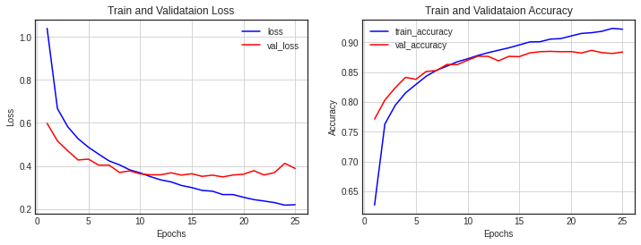

```python
history_2_dict = hist_2.history
loss = history_2_dict['loss']
val_loss = history_2_dict['val_loss']
accuracy = history_2_dict['accuracy']
val_accuracy = history_2_dict['val_accuracy']
epochs = range(1, len(loss) + 1)

plt.figure(figsize = (12 , 4))

ax1 = plt.subplot(1, 2, 1)
ax1.plot(epochs, loss, color = 'blue', label = 'loss')
ax1.plot(epochs, val_loss, color = 'red', label = 'val_loss')
ax1.set_title('Train and Validataion Loss')
ax1.set_xlabel('Epochs')
ax1.set_ylabel('Loss')
ax1.grid()
ax1.legend()

ax2 = plt.subplot(1, 2, 2)
ax2.plot(epochs, accuracy, color = 'blue', label = 'train_accuracy')
ax2.plot(epochs, val_accuracy, color = 'red', label = 'val_accuracy')
ax2.set_title('Train and Validataion Accuracy')
ax2.set_xlabel('Epochs')
ax2.set_ylabel('Accuracy')
ax2.grid()
ax2.legend()
plt.show()
```

### 모델 재평가

```python
model_2.evaluate(x_test, y_test)
```

```
[55.976524353027344, 0.8604999780654907]
```

## 모델 성능 높이기 - 많은 레이어 쌓기

```python
from tensorflow.keras.layers import BatchNormalization, ReLU
```

```python
def build_model3():
  model = Sequential()

  input = Input(shape = (28, 28, 1))
  output = Conv2D(filters = 32, kernel_size = (3, 3), activation = 'relu', padding = 'same')(input)
  output = Conv2D(filters = 64, kernel_size = (3, 3), activation = 'relu', padding = 'valid')(output)
  output = MaxPool2D(strides = (2,2))(output)
  output = Dropout(0.5)(output)

  output = Conv2D(filters = 128, kernel_size = (3, 3), activation = 'relu', padding = 'same')(output)
  output = Conv2D(filters = 256, kernel_size = (3, 3), activation = 'relu', padding = 'valid')(output)
  output = MaxPool2D(strides = (2,2))(output)
  output = Dropout(0.5)(output)

  output = Flatten()(output)
  output = Dense(256, activation = 'relu')(output)
  output = Dropout(0.5)(output)
  output = Dense(100, activation = 'relu')(output)
  output = Dropout(0.5)(output)
  output = Dense(10, activation = 'softmax')(output)

  model = Model(inputs = [input], outputs = output)

  model.compile(optimizer = 'adam',
                loss = 'sparse_categorical_crossentropy',
                metrics = ['accuracy'])

  return model

model_3 = build_model3()
model_3.summary()
```

```
Model: "model_10"
_________________________________________________________________
 Layer (type)                Output Shape              Param #
=================================================================
 input_11 (InputLayer)       [(None, 28, 28, 1)]       0

 conv2d_30 (Conv2D)          (None, 28, 28, 32)        320

 conv2d_31 (Conv2D)          (None, 26, 26, 64)        18496

 max_pooling2d_9 (MaxPooling  (None, 13, 13, 64)       0
 2D)

 dropout_6 (Dropout)         (None, 13, 13, 64)        0

 conv2d_32 (Conv2D)          (None, 13, 13, 128)       73856

 conv2d_33 (Conv2D)          (None, 11, 11, 256)       295168

 max_pooling2d_10 (MaxPoolin  (None, 5, 5, 256)        0
 g2D)

 dropout_7 (Dropout)         (None, 5, 5, 256)         0

 flatten_10 (Flatten)        (None, 6400)              0

 dense_30 (Dense)            (None, 256)               1638656

 dropout_8 (Dropout)         (None, 256)               0

 dense_31 (Dense)            (None, 100)               25700

 dropout_9 (Dropout)         (None, 100)               0

 dense_32 (Dense)            (None, 10)                1010

=================================================================
Total params: 2,053,206
Trainable params: 2,053,206
Non-trainable params: 0
_________________________________________________________________
```

## 모델 학습 및 결과 시각화

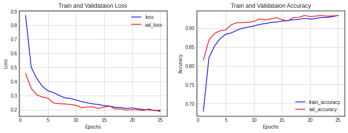

```python
hist_3 = model_3.fit(x_train, y_train,
                   epochs = 25,
                   validation_split = 0.3,
                   batch_size = 128, verbose = False)

history_3_dict = hist_3.history
loss = history_3_dict['loss']
val_loss = history_3_dict['val_loss']
accuracy = history_3_dict['accuracy']
val_accuracy = history_3_dict['val_accuracy']
epochs = range(1, len(loss) + 1)

plt.figure(figsize = (12 , 4))

ax1 = plt.subplot(1, 2, 1)
ax1.plot(epochs, loss, color = 'blue', label = 'loss')
ax1.plot(epochs, val_loss, color = 'red', label = 'val_loss')
ax1.set_title('Train and Validataion Loss')
ax1.set_xlabel('Epochs')
ax1.set_ylabel('Loss')
ax1.grid()
ax1.legend()

ax2 = plt.subplot(1, 2, 2)
ax2.plot(epochs, accuracy, color = 'blue', label = 'train_accuracy')
ax2.plot(epochs, val_accuracy, color = 'red', label = 'val_accuracy')
ax2.set_title('Train and Validataion Accuracy')
ax2.set_xlabel('Epochs')
ax2.set_ylabel('Accuracy')
ax2.grid()
ax2.legend()
plt.show()
```

```python
model_3.evaluate(x_test, y_test)
```

```
[33.597537994384766, 0.7932000160217285]
```

## 모델 성능 높이기 - 이미지 보강(Image Augmentation)

- 주요 인자 참고: https://keras.io/ko/preprocessing/image/

```python
from tensorflow.keras.preprocessing.image import ImageDataGenerator
```

```python
image_generator = ImageDataGenerator(
    rotation_range = 10,
    zoom_range = 0.2,
    shear_range = 0.6,
    width_shift_range = 0.1,
    height_shift_range = 0.1,
    horizontal_flip = True,
    vertical_flip = False
)
```

```python
augment_size = 200
```

```python
x_train.shape, x_train[0].shape
```

```
((60000, 28, 28, 1), (28, 28, 1))
```

```python
x_augment = image_generator.flow(np.tile(x_train[0].reshape(28*28*1), augment_size).reshape(-1, 28, 28, 1),
                                 np.zeros(augment_size), batch_size = augment_size, shuffle = False).next()[0]
```

[figure not shown]

```python
plt.figure(figsize = (10, 10))
for i in range(1, 10):
  plt.subplot(10, 10, i)
  plt.axis('off')
  plt.imshow(x_augment[i-1].reshape(28, 28), cmap = 'gray')
```

데이터 추가

```python
image_generator = ImageDataGenerator(
    rotation_range = 15,
    zoom_range = 0.1,
    shear_range = 0.6,
    width_shift_range = 0.15,
    height_shift_range = 0.1,
    horizontal_flip = True,
    vertical_flip = False
)
```

```python
augment_size = 30000
```

```python
random_mask = np.random.randint(x_train.shape[0], size = augment_size)
x_augmented = x_train[random_mask].copy()
y_augmented = y_train[random_mask].copy()
```

```python
x_augmented = image_generator.flow(x_augmented, np.zeros(augment_size),
                                 batch_size = augment_size, shuffle = False).next()[0]

x_train = np.concatenate((x_train, x_augmented))
y_train = np.concatenate((y_train, y_augmented))

x_train.shape, y_train.shape
```

```
((90000, 28, 28, 1), (90000,))
```

## 모델 학습 및 결과 시각화

```python
model_4 = build_model3()
model_4.summary()
```

```
Model: "model_11"
_________________________________________________________________
 Layer (type)                Output Shape              Param #
=================================================================
 input_12 (InputLayer)       [(None, 28, 28, 1)]       0

 conv2d_34 (Conv2D)          (None, 28, 28, 32)        320

 conv2d_35 (Conv2D)          (None, 26, 26, 64)        18496

 max_pooling2d_11 (MaxPoolin  (None, 13, 13, 64)       0
 g2D)

 dropout_10 (Dropout)        (None, 13, 13, 64)        0

 conv2d_36 (Conv2D)          (None, 13, 13, 128)       73856

 conv2d_37 (Conv2D)          (None, 11, 11, 256)       295168

 max_pooling2d_12 (MaxPoolin  (None, 5, 5, 256)        0
 g2D)

 dropout_11 (Dropout)        (None, 5, 5, 256)         0

 flatten_11 (Flatten)        (None, 6400)              0

 dense_33 (Dense)            (None, 256)               1638656

 dropout_12 (Dropout)        (None, 256)               0

 dense_34 (Dense)            (None, 100)               25700

 dropout_13 (Dropout)        (None, 100)               0

 dense_35 (Dense)            (None, 10)                1010

=================================================================
Total params: 2,053,206
Trainable params: 2,053,206
Non-trainable params: 0
_________________________________________________________________
```

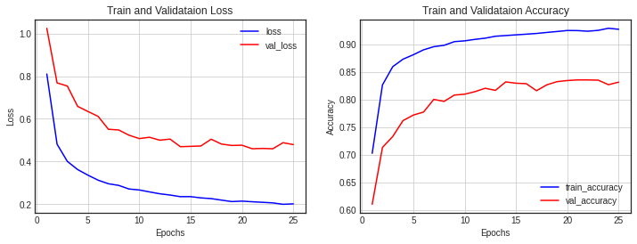

```python
hist_4 = model_4.fit(x_train, y_train,
                   epochs = 25,
                   validation_split = 0.3,
                   batch_size = 128, verbose = False)

history_4_dict = hist_4.history
loss = history_4_dict['loss']
val_loss = history_4_dict['val_loss']
accuracy = history_4_dict['accuracy']
val_accuracy = history_4_dict['val_accuracy']
epochs = range(1, len(loss) + 1)

plt.figure(figsize = (12 , 4))

ax1 = plt.subplot(1, 2, 1)
ax1.plot(epochs, loss, color = 'blue', label = 'loss')
ax1.plot(epochs, val_loss, color = 'red', label = 'val_loss')
ax1.set_title('Train and Validataion Loss')
ax1.set_xlabel('Epochs')
ax1.set_ylabel('Loss')
ax1.grid()
ax1.legend()

ax2 = plt.subplot(1, 2, 2)
ax2.plot(epochs, accuracy, color = 'blue', label = 'train_accuracy')
ax2.plot(epochs, val_accuracy, color = 'red', label = 'val_accuracy')
ax2.set_title('Train and Validataion Accuracy')
ax2.set_xlabel('Epochs')
ax2.set_ylabel('Accuracy')
ax2.grid()
ax2.legend()
plt.show()
```

- 학습 인자를 이전과 다르게 주면서 학습하면 더 잘 나올것으로 판단

```python
model_4.evaluate(x_test, y_test)
```

```
[49.786128997802734, 0.7797999978065491]
```

## 예제로 보는 CNN 구조와 학습

- 모델 구현은 참고만
- [런타임] - [런타임 유형변경] - GPU 변경

### 일반적인 구조

#### modules import

```python
%load_ext tensorboard
```

```python
import datetime
import numpy as np
import tensorflow as tf
import matplotlib.pyplot as plt
plt.style.use('seaborn-white')

from tensorflow.keras import Model
from tensorflow.keras.models import Sequential
from tensorflow.keras.layers import Dense, Flatten, MaxPool2D, Conv2D, AvgPool2D, Dropout

from tensorflow.keras import datasets
from tensorflow.keras.utils import to_categorical, plot_model
```

#### 데이터 로드 및 전처리

```python
(x_train, y_train) , (x_test, y_test) = datasets.fashion_mnist.load_data()
```

```python
x_train.shape, y_train.shape, x_test.shape, y_test.shape
```

```
((60000, 28, 28), (60000,), (10000, 28, 28), (10000,))
```

```python
# 3차원 데이터 4차원으로 변환
x_train = x_train[:, :, :, np.newaxis]
x_test = x_test[:, :, :, np.newaxis]

x_train.shape, y_train.shape, x_test.shape, y_test.shape
```

```
((60000, 28, 28, 1), (60000,), (10000, 28, 28, 1), (10000,))
```

```python
# 원핫 인코딩
num_classes = 10

y_train = to_categorical(y_train, num_classes)
y_test = to_categorical(y_test, num_classes)
```

```python
y_train.shape, y_test.shape
```

```
((60000, 10), (10000, 10))
```

```python
x_train = x_train.astype('float32')
x_test = x_test.astype('float32')
x_train /= 255
x_test /= 255
```

#### CNN을 위한 간단한 모델

```python
def build() :
  model = Sequential([Conv2D(64, 7, activation = 'relu', padding = 'same', input_shape = [28, 28, 1]), # 필터 64개, 필터 크기 7 X 7
                      MaxPool2D(pool_size = 2), # 풀링 크기 2 X 2
                      Conv2D(128, 3, activation = 'relu', padding = 'same'), # 필터 128개, 필터 크기 3 X 3
                      MaxPool2D(pool_size = 2), # 풀링 크기 2 X 2
                      Conv2D(256, 3, activation = 'relu', padding = 'same'),
                      MaxPool2D(2),
                      Flatten(),
                      Dense(128, activation = 'relu'),
                      Dropout(0.5),
                      Dense(64, activation = 'relu'),
                      Dropout(0.5),
                      Dense(10, activation = 'softmax')])

  return model
```

#### 모델 컴파일

```python
model = build()

model.compile(optimizer = 'adam',
              loss = 'categorical_crossentropy',
              metrics = ['accuracy'])
```

```python
print(model.summary())
```

```
Model: "sequential_1"
_________________________________________________________________
 Layer (type)                Output Shape              Param #
=================================================================
 conv2d_4 (Conv2D)           (None, 28, 28, 64)        3200

 max_pooling2d_3 (MaxPooling  (None, 14, 14, 64)       0
 2D)

 conv2d_5 (Conv2D)           (None, 14, 14, 128)       73856

 max_pooling2d_4 (MaxPooling  (None, 7, 7, 128)        0
 2D)

 conv2d_6 (Conv2D)           (None, 7, 7, 256)         295168

 max_pooling2d_5 (MaxPooling  (None, 3, 3, 256)        0
 2D)

 flatten_1 (Flatten)         (None, 2304)              0

 dense_3 (Dense)             (None, 128)               295040

 dropout_2 (Dropout)         (None, 128)               0

 dense_4 (Dense)             (None, 64)                8256

 dropout_3 (Dropout)         (None, 64)                0

 dense_5 (Dense)             (None, 10)                650

=================================================================
Total params: 676,170
Trainable params: 676,170
Non-trainable params: 0
_________________________________________________________________
None
```

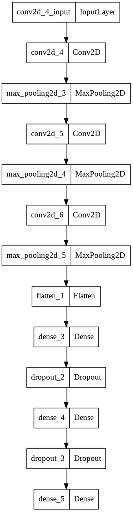

```python
plot_model(model)
```

```python
callbacks = [tf.keras.callbacks.TensorBoard(log_dir = '.logs', histogram_freq = 0,
            write_graph = True, write_images = True)]
```

#### Hyper Parameters

```python
EPOCHS = 20
BATCH_SIZE = 200
```

#### 모델 학습

- `validation_split` 을 통해 검증 데이터셋을 생성

```python
hist = model.fit(x_train, y_train,
                 epochs = EPOCHS,
                 batch_size = BATCH_SIZE,
                 validation_split = 0.3,
                 callbacks = callbacks,
                 verbose = False)
```

```python
log_dir = '.logs'
```

```python
%tensorboard --logdir {log_dir}
```

```
Reusing TensorBoard on port 6007 (pid 518), started 0:04:06 ago. (Use '!kill 518' to kill it.)
```

### LeNet-5

- 필기체 인식을 위한 모델

[figure not shown]

  <sub>https://www.researchgate.net/figure/The-LeNet-5-Architecture-a-convolutional-neural-network_fig4_321586653</sub>
- 코드 출처 : http://datahacker.rs/lenet-5-implementation-tensorflow-2-0/

#### module import

```python
import datetime
import numpy as np
import tensorflow as tf
import matplotlib.pyplot as plt
plt.style.use('seaborn-white')

from tensorflow.keras import Model
from tensorflow.keras.models import Sequential
from tensorflow.keras.layers import Dense, Flatten, MaxPool2D, Conv2D, AvgPool2D, Dropout

from tensorflow.keras import datasets
from tensorflow.keras.utils import to_categorical, plot_model

from sklearn.model_selection import train_test_split
```

#### 데이터 로드 및 전처리

```python
(x_train_full, y_train_full), (x_test, y_test) = datasets.mnist.load_data()

x_train, x_val, y_train, y_val = train_test_split(x_train_full, y_train_full,
                                                  test_size = 0.3,
                                                  random_state = 777)

x_train = x_train[..., np.newaxis]
x_val = x_val[..., np.newaxis]
x_test = x_test[..., np.newaxis]

num_classes = 10
y_train = to_categorical(y_train, num_classes)
y_val = to_categorical(y_val, num_classes)
y_test = to_categorical(y_test, num_classes)

x_train = x_train.astype('float32')
x_val = x_val.astype('float32')
x_test = x_test.astype('float32')

x_train /= 255.
x_val /= 255.
x_test /= 255.

x_train.shape, x_val.shape, x_test.shape, y_train.shape, y_val.shape, y_test.shape
```

```
((42000, 28, 28, 1),
 (18000, 28, 28, 1),
 (10000, 28, 28, 1),
 (42000, 10),
 (18000, 10),
 (10000, 10))
```

#### 모델 구성 및 컴파일

```python
class LeNet(Sequential):
  def __init__(self, input_shape, nb_classes):
    super().__init__()

    self.add(Conv2D(6, kernel_size = (5, 5), strides = (1,1), activation = 'tanh', input_shape = input_shape, padding = 'same'))
    self.add(AvgPool2D(pool_size = (2, 2), strides = (2, 2), padding = 'valid'))
    self.add(Conv2D(16, kernel_size = (5, 5), strides = (1, 1), activation = 'tanh', padding = 'valid'))
    self.add(AvgPool2D(pool_size = (2, 2), strides = (2, 2), padding = 'valid'))
    self.add(Flatten())
    self.add(Dense(120, activation = 'tanh'))
    self.add(Dense(84, activation = 'tanh'))
    self.add(Dense(nb_classes, activation = 'softmax'))

    self.compile(optimizer = 'adam',
              loss = 'categorical_crossentropy',
              metrics = ['accuracy'])
```

```python
model = LeNet(input_shape = (28, 28, 1), nb_classes = 10)
```

```python
model.summary()
```

```
Model: "le_net_6"
_________________________________________________________________
 Layer (type)                Output Shape              Param #
=================================================================
 conv2d_19 (Conv2D)          (None, 28, 28, 6)         156

 average_pooling2d_12 (Avera  (None, 14, 14, 6)        0
 gePooling2D)

 conv2d_20 (Conv2D)          (None, 10, 10, 16)        2416

 average_pooling2d_13 (Avera  (None, 5, 5, 16)         0
 gePooling2D)

 flatten_8 (Flatten)         (None, 400)               0

 dense_24 (Dense)            (None, 120)               48120

 dense_25 (Dense)            (None, 84)                10164

 dense_26 (Dense)            (None, 10)                850

=================================================================
Total params: 61,706
Trainable params: 61,706
Non-trainable params: 0
_________________________________________________________________
```

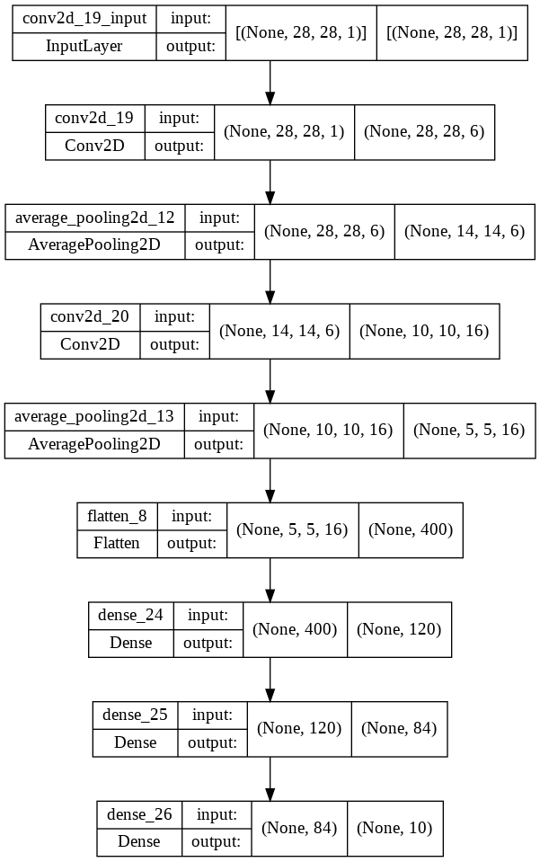

```python
plot_model(model, show_shapes = True)
```

#### Hyper Parameters

```python
EPOChS = 20
BATCH_SIZE = 128
```

#### 모델 학습

```python
hist = model.fit(x_train, y_train,
                 epochs = EPOCHS,
                 batch_size = BATCH_SIZE,
                 validation_data = (x_val, y_val),
                 verbose = False)
```

#### 학습 결과 시각화

```python
import matplotlib.pyplot as plt
plt.style.use('seaborn-white')
```

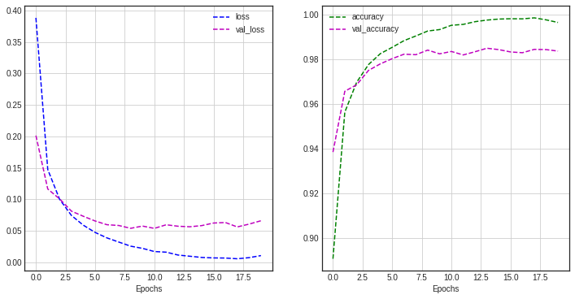

```python
plt.figure(figsize = (12, 6))

plt.subplot(1, 2, 1)
plt.plot(hist.history['loss'], 'b--', label = 'loss')
plt.plot(hist.history['val_loss'], 'm--', label = 'val_loss')
plt.xlabel('Epochs')
plt.grid()
plt.legend()

plt.subplot(1, 2, 2)
plt.plot(hist.history['accuracy'], 'g--', label = 'accuracy')
plt.plot(hist.history['val_accuracy'], 'm--', label = 'val_accuracy')
plt.xlabel('Epochs')
plt.grid()
plt.legend()
plt.show()
```

#### 모델 평가

```python
model.evaluate(x_test, y_test)
```

```
[0.059864386916160583, 0.9835000038146973]
```

# 03 케라스 CNN CIFAR 10

- 50,000개의 학습데이터, 10,000개의 테스트 데이터로 구성
- 데이터 복잡도가 MNIST보다 훨씬 높은 특징이 있음
  - 신경망이 특징을 검출하기 어려움

[figure not shown]

### modules import

```python
import tensorflow as tf
from tensorflow.keras.datasets import cifar10
from tensorflow.keras.layers import Conv2D, MaxPool2D, Dense, Flatten, Input, Dropout, BatchNormalization
from tensorflow.keras.models import Sequential, Model
from tensorflow.keras.optimizers import Adam
from tensorflow.keras.utils import to_categorical

from sklearn.model_selection import train_test_split

import matplotlib.pyplot as plt
plt.style.use('seaborn-white')

import numpy as np
```

### 데이터 로드 및 전처리

```python
(x_train_full, y_train_full), (x_test, y_test) = cifar10.load_data()

x_train_full.shape, y_train_full.shape, x_test.shape, y_test.shape
```

```
((50000, 32, 32, 3), (50000, 1), (10000, 32, 32, 3), (10000, 1))
```

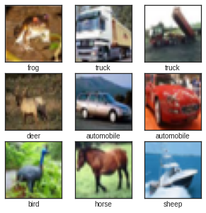

```python
np.random.seed(777)

class_names = ['airplane', 'automobile', 'bird', 'cat', 'deer',
               'dog', 'frog', 'horse', 'sheep', 'truck']
sample_size = 9
random_idx = np.random.randint(60000, size = sample_size)

plt.figure(figsize = (5, 5))
for i, idx in enumerate(random_idx):
  plt.subplot(3, 3, i+1)
  plt.xticks([])
  plt.yticks([])
  plt.imshow(x_train_full[i])
  plt.xlabel(class_names[int(y_train_full[i])])
```

```python
x_mean = np.mean(x_train_full, axis = (0, 1, 2))
x_std = np.std(x_train_full, axis = (0, 1, 2))

x_train_full = (x_train_full - x_mean) / x_std
x_test = (x_test - x_mean) / x_std
```

```python
x_train, x_val, y_train, y_val = train_test_split(x_train_full, y_train_full, test_size = 0.3)
```

```python
x_train.shape, y_val.shape, x_test.shape, y_train.shape, y_val.shape, y_test.shape
```

```
((35000, 32, 32, 3),
 (15000, 1),
 (10000, 32, 32, 3),
 (35000, 1),
 (15000, 1),
 (10000, 1))
```

### 모델 구성 및 컴파일

```python
def build_model() :
  model = Sequential()

  input = Input(shape = (32, 32, 3))

  output = Conv2D(filters = 32, kernel_size = 3, padding = 'same', activation = 'relu')(input)
  output = MaxPool2D(pool_size = (2, 2), strides = 2, padding = 'same')(output)

  output = Conv2D(filters = 64, kernel_size = 3, padding = 'same', activation = 'relu')(output)
  output = MaxPool2D(pool_size = (2, 2), strides = 2, padding = 'same')(output)

  output = Conv2D(filters = 128, kernel_size = 3, padding = 'same', activation = 'relu')(output)
  output = MaxPool2D(pool_size = (2, 2), strides = 2, padding = 'same')(output)

  output = Flatten()(output)
  output = Dense(256, activation = 'relu')(output)
  output = Dense(128, activation = 'relu')(output)
  output = Dense(10, activation = 'softmax')(output)

  model = Model(inputs = [input], outputs = output)

  model.compile(loss = 'sparse_categorical_crossentropy',
                optimizer = Adam(1e-4),
                metrics = ['accuracy'])

  return model
```

```python
model = build_model()
model.summary()
```

```
Model: "model_2"
_________________________________________________________________
 Layer (type)                Output Shape              Param #
=================================================================
 input_3 (InputLayer)        [(None, 32, 32, 3)]       0

 conv2d_6 (Conv2D)           (None, 32, 32, 32)        896

 max_pooling2d_6 (MaxPooling  (None, 16, 16, 32)       0
 2D)

 conv2d_7 (Conv2D)           (None, 16, 16, 64)        18496

 max_pooling2d_7 (MaxPooling  (None, 8, 8, 64)         0
 2D)

 conv2d_8 (Conv2D)           (None, 8, 8, 128)         73856

 max_pooling2d_8 (MaxPooling  (None, 4, 4, 128)        0
 2D)

 flatten_2 (Flatten)         (None, 2048)              0

 dense_6 (Dense)             (None, 256)               524544

 dense_7 (Dense)             (None, 128)               32896

 dense_8 (Dense)             (None, 10)                1290

=================================================================
Total params: 651,978
Trainable params: 651,978
Non-trainable params: 0
_________________________________________________________________
```

### 모델 학습 및 평가

- [런타임]에서 GPU 설정

```python
history = model.fit(x_train, y_train,
                    epochs = 30,
                    batch_size = 256,
                    validation_data = (x_val, y_val), verbose = False)
```

### 학습 과정 시각화

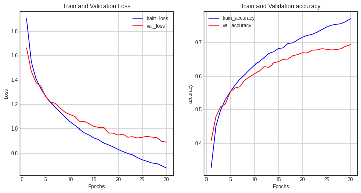

```python
history_dict = history.history

loss = history_dict['loss']
val_loss = history_dict['val_loss']

epochs = range(1, len(loss) + 1)
fig = plt.figure(figsize = (12, 6))

ax1 = fig.add_subplot(1, 2, 1)
ax1.plot(epochs, loss, color = 'blue', label = 'train_loss')
ax1.plot(epochs, val_loss, color = 'red', label = 'val_loss')
ax1.set_title('Train and Validation Loss')
ax1.set_xlabel("Epochs")
ax1.set_ylabel("Loss")
ax1.grid()
ax1.legend()

mae = history_dict['accuracy']
val_mae = history_dict['val_accuracy']

ax2 = fig.add_subplot(1, 2, 2)
ax2.plot(epochs, mae, color = 'blue', label = 'train_accuracy')
ax2.plot(epochs, val_mae, color = 'red', label = 'val_accuracy')
ax2.set_title('Train and Validation accuracy')
ax2.set_xlabel("Epochs")
ax2.set_ylabel("accuracy")
ax2.grid()
ax2.legend()
```

- 해당 모델은 성능이 좋지 않음
- 규제화, 드롭아웃 등 과대적합을 방지하는 기술 필요

```python
def build_model2() :
  model = Sequential()

  input = Input(shape = (32, 32, 3))

  output = Conv2D(filters = 32, kernel_size = 3, padding = 'same', activation = 'relu')(input)
  output = BatchNormalization()(output)
  output = MaxPool2D(pool_size = (2, 2), strides = 2, padding = 'same')(output)

  output = Conv2D(filters = 64, kernel_size = 3, padding = 'same', activation = 'relu')(output)
  output = BatchNormalization()(output)
  output = MaxPool2D(pool_size = (2, 2), strides = 2, padding = 'same')(output)

  output = Conv2D(filters = 128, kernel_size = 3, padding = 'same', activation = 'relu')(output)
  output = BatchNormalization()(output)
  output = MaxPool2D(pool_size = (2, 2), strides = 2, padding = 'same')(output)
  output = Dropout(0.5)(output)

  output = Flatten()(output)
  output = Dense(256, activation = 'relu')(output)
  output = Dropout(0.5)(output)
  output = Dense(128, activation = 'relu')(output)
  output = Dense(10, activation = 'softmax')(output)

  model = Model(inputs = [input], outputs = output)

  model.compile(loss = 'sparse_categorical_crossentropy',
                optimizer = Adam(1e-4),
                metrics = ['accuracy'])

  return model
```

```python
model2 = build_model2()
model2.summary()
```

```
Model: "model_3"
_________________________________________________________________
 Layer (type)                Output Shape              Param #
=================================================================
 input_4 (InputLayer)        [(None, 32, 32, 3)]       0

 conv2d_9 (Conv2D)           (None, 32, 32, 32)        896

 batch_normalization (BatchN  (None, 32, 32, 32)       128
 ormalization)

 max_pooling2d_9 (MaxPooling  (None, 16, 16, 32)       0
 2D)

 conv2d_10 (Conv2D)          (None, 16, 16, 64)        18496

 batch_normalization_1 (Batc  (None, 16, 16, 64)       256
 hNormalization)

 max_pooling2d_10 (MaxPoolin  (None, 8, 8, 64)         0
 g2D)

 conv2d_11 (Conv2D)          (None, 8, 8, 128)         73856

 batch_normalization_2 (Batc  (None, 8, 8, 128)        512
 hNormalization)

 max_pooling2d_11 (MaxPoolin  (None, 4, 4, 128)        0
 g2D)

 dropout (Dropout)           (None, 4, 4, 128)         0

 flatten_3 (Flatten)         (None, 2048)              0

 dense_9 (Dense)             (None, 256)               524544

 dropout_1 (Dropout)         (None, 256)               0

 dense_10 (Dense)            (None, 128)               32896

 dense_11 (Dense)            (None, 10)                1290

=================================================================
Total params: 652,874
Trainable params: 652,426
Non-trainable params: 448
_________________________________________________________________
```

```python
history_2 = model2.fit(x_train, y_train,
                    epochs = 30,
                    batch_size = 256,
                    validation_data = (x_val, y_val), verbose = False)
```

### 모델 학습 및 평가

- [런타임]에서 GPU 설정

```python
model2.evaluate(x_test, y_test)
```

```
[30.612136840820312, 0.3010999858379364]
```

### 학습 과정 시각화

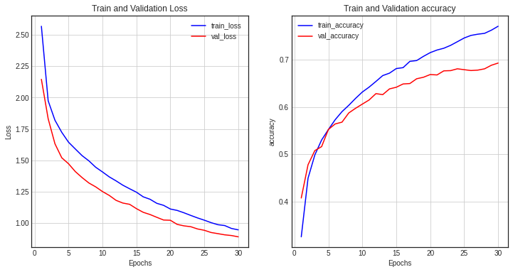

```python
history_dict2 = history_2.history

loss = history_dict2['loss']
val_loss = history_dict2['val_loss']

epochs = range(1, len(loss) + 1)
fig = plt.figure(figsize = (12, 6))

ax1 = fig.add_subplot(1, 2, 1)
ax1.plot(epochs, loss, color = 'blue', label = 'train_loss')
ax1.plot(epochs, val_loss, color = 'red', label = 'val_loss')
ax1.set_title('Train and Validation Loss')
ax1.set_xlabel("Epochs")
ax1.set_ylabel("Loss")
ax1.grid()
ax1.legend()

mae = history_dict['accuracy']
val_mae = history_dict['val_accuracy']

ax2 = fig.add_subplot(1, 2, 2)
ax2.plot(epochs, mae, color = 'blue', label = 'train_accuracy')
ax2.plot(epochs, val_mae, color = 'red', label = 'val_accuracy')
ax2.set_title('Train and Validation accuracy')
ax2.set_xlabel("Epochs")
ax2.set_ylabel("accuracy")
ax2.grid()
ax2.legend()
plt.show()
```

# 04 케라스 전이 학습(Transfer Learning)

## 전이 학습(Transfer Learning)은 특정 분야에서 학습된 신경망의 일부 능력을, 유사하거나 전혀 새로운 분야에서 사용되는 신경망의 학습에 이용하는 것을 의미합니다.

[figure not shown]

<sub>출처: https://medium.com/the-official-integrate-ai-blog/transfer-learning-explained-7d275c1e34e2</sub>

```python
import tensorflow as tf
from tensorflow.keras.models import Sequential
from tensorflow.keras.layers import Conv2D, Dense, Flatten, MaxPool2D, BatchNormalization, Activation
from tensorflow.keras.optimizers import Adam, RMSprop
from tensorflow.keras.preprocessing.image import ImageDataGenerator
from tensorflow.keras.applications import *
```

```python
vgg16 = VGG16(weights = 'imagenet',
              input_shape = (32, 32, 3), include_top = False) # vgg16의 분류기층은 포함X
```

```
Downloading data from https://storage.googleapis.com/tensorflow/keras-applications/vgg16/vgg16_weights_tf_dim_ordering_tf_kernels_notop.h5
```

```python
model = Sequential()
model.add(vgg16)
model.summary()
```

```
Model: "sequential"
_________________________________________________________________
 Layer (type)                Output Shape              Param #
=================================================================
 vgg16 (Functional)          (None, 1, 1, 512)         14714688

=================================================================
Total params: 14,714,688
Trainable params: 14,714,688
Non-trainable params: 0
_________________________________________________________________
```

```python
model.add(Flatten())
model.add(Dense(256))
model.add(BatchNormalization())
model.add(Activation('relu'))
model.add(Dense(10, activation = 'softmax'))

model.summary()
```

```
Model: "sequential"
_________________________________________________________________
 Layer (type)                Output Shape              Param #
=================================================================
 vgg16 (Functional)          (None, 1, 1, 512)         14714688

 flatten (Flatten)           (None, 512)               0

 dense (Dense)               (None, 256)               131328

 batch_normalization (BatchN  (None, 256)              1024
 ormalization)

 activation (Activation)     (None, 256)               0

 dense_1 (Dense)             (None, 10)                2570

=================================================================
Total params: 14,849,610
Trainable params: 14,849,098
Non-trainable params: 512
_________________________________________________________________
```

```python
# 그 외 모델
mobilenet = MobileNet(weights = None, input_shape = None, include_top = True) # 해당 모델의 가중치와, 층의 뉴런개수는 미포함

resnet50 = ResNet50(weights = None, input_shape = None, include_top = True) # 해당 모델의 가중치와, 층의 뉴런개수는 미포함

xception = Xception(weights = None, input_shape = None, include_top = True) # 해당 모델의 가중치와, 층의 뉴런개수는 미포함
```

### 예제 : Dogs vs Cats

- Kaggle Data 이용: https://www.kaggle.com/c/dogs-vs-cats/data
- ImageDataGenerator의 flow_from_directory 이용
- 런타임 유형 GPU 사용
- 출처: https://colab.research.google.com/github/google/eng-edu/blob/master/ml/pc/exercises/image_classification_part2.ipynb#scrollTo=SdW6geEVi2S8

#### modules import

```python
import tensorflow as tf
from tensorflow.keras.preprocessing.image import array_to_img, img_to_array, load_img
from tensorflow.keras.layers import Conv2D, Dense, Flatten, MaxPool2D, Input, Dropout
from tensorflow.keras import Model
from tensorflow.keras.optimizers import Adam

import os
import zipfile
import matplotlib.image as mpimg
import matplotlib.pyplot as plt
plt.style.use('seaborn-white')
```

#### 데이터 로드

```python
local_zip = '/content/cats_and_dogs_filtered.zip'
zip_ref = zipfile.ZipFile(local_zip, 'r') # 압축파일 읽기
zip_ref.extractall('/content') # 압축파일 추출
zip_ref.close() # 압축파일 닫기
```

```python
base_dir = '/content/cats_and_dogs_filtered' # 압축파일 경로
train_dir = os.path.join(base_dir, 'train') # base_dir(압축파일)에 있는 train폴더를 train으로
validation_dir = os.path.join(base_dir, 'validation') # base_dir(압축파일)에 있는 validataion폴더를 validataion으로
```

```python
train_cats_dir = os.path.join(train_dir, 'cats') # train폴더안의 cats폴더 위치
train_dogs_dir = os.path.join(train_dir, 'dogs')
validation_cats_dir = os.path.join(train_dir, 'cats')
validation_dogs_dir = os.path.join(train_dir, 'dogs')

train_cat_fnames = os.listdir(train_cats_dir) # train_cats_dir안의 파일(이미지)들의 리스트
train_dog_fnames = os.listdir(train_dogs_dir)
```

#### 이미지 보강된 데이터 확인

```python
datagen = ImageDataGenerator(
    rotation_range = 40,
    width_shift_range = 0.2,
    height_shift_range = 0.2,
    shear_range = 0.2,
    zoom_range = 0.2,
    horizontal_flip = True,
    fill_mode = 'nearest'
)
```

```python
img_path = os.path.join(train_cats_dir, train_cat_fnames[2]) # 고양이 훈련데이터의 3번째 이미지
img = load_img(img_path, target_size = (150, 150)) # 이미지 로드(150 X 150)

x = img_to_array(img) # 이미지를 array로 변환
print(x.shape)
x = x.reshape((1,) + x.shape) # 4차원으로 변환
print(x.shape)
```

```
(150, 150, 3)
(1, 150, 150, 3)
```

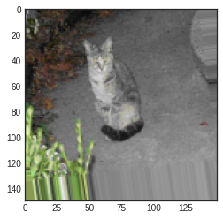

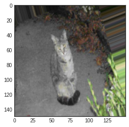

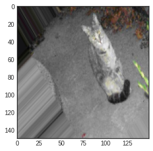

```python
# generator적용한 고양이의 3번째 이미지를 3개 확인
i = 0
for batch in datagen.flow(x, batch_size = 1):
  plt.figure(i)
  imgplot = plt.imshow(array_to_img(batch[0]))
  i += 1
  if i % 3 == 0:
    break
```

#### 학습, 검증 데이터셋의 Data Generator

```python
# train데이터, validation데이터 Generator 일괄적용
train_datagen = ImageDataGenerator(
    rescale = 1./ 255,
    rotation_range = 40,
    width_shift_range = 0.2,
    height_shift_range = 0.2,
    shear_range = 0.2,
    zoom_range = 0.2,
    horizontal_flip = True
)

train_generator = train_datagen.flow_from_directory(
    train_dir,
    target_size = (150, 150),
    batch_size = 20,
    class_mode = 'binary'
)

val_datagen = ImageDataGenerator(rescale = 1/255)

validataion_generator = val_datagen.flow_from_directory(
    validation_dir,
    target_size = (150, 150),
    batch_size = 20,
    class_mode = 'binary'
)
```

```
Found 2000 images belonging to 2 classes.
Found 1000 images belonging to 2 classes.
```

#### 모델 구성 및 컴파일

```python
model = Sequential()
model.add(Conv2D(32, (3, 3), activation = 'relu', input_shape = (150, 150, 3)))
model.add(MaxPool2D(2, 2))
model.add(Conv2D(64, (3, 3), activation = 'relu'))
model.add(MaxPool2D(2, 2))
model.add(Conv2D(128, (3, 3), activation = 'relu'))
model.add(MaxPool2D(2, 2))
model.add(Conv2D(128, (3, 3), activation = 'relu'))
model.add(MaxPool2D(2, 2))

model.add(Flatten())
model.add(Dropout(0.5))
model.add(Dense(512, activation = 'relu'))
model.add(Dense(1, activation = 'sigmoid'))

model.compile(loss = 'binary_crossentropy',
              optimizer = Adam(1e-4),
              metrics = ['acc'])
model.summary()
```

```
Model: "sequential_2"
_________________________________________________________________
 Layer (type)                Output Shape              Param #
=================================================================
 conv2d_8 (Conv2D)           (None, 148, 148, 32)      896

 max_pooling2d_4 (MaxPooling  (None, 74, 74, 32)       0
 2D)

 conv2d_9 (Conv2D)           (None, 72, 72, 64)        18496

 max_pooling2d_5 (MaxPooling  (None, 36, 36, 64)       0
 2D)

 conv2d_10 (Conv2D)          (None, 34, 34, 128)       73856

 max_pooling2d_6 (MaxPooling  (None, 17, 17, 128)      0
 2D)

 conv2d_11 (Conv2D)          (None, 15, 15, 128)       147584

 max_pooling2d_7 (MaxPooling  (None, 7, 7, 128)        0
 2D)

 flatten_2 (Flatten)         (None, 6272)              0

 dropout_1 (Dropout)         (None, 6272)              0

 dense_4 (Dense)             (None, 512)               3211776

 dense_5 (Dense)             (None, 1)                 513

=================================================================
Total params: 3,453,121
Trainable params: 3,453,121
Non-trainable params: 0
_________________________________________________________________
```

#### 모델 학습 및 학습 과정 시각화

- 런타임유형 GPU 사용

```python
history = model.fit(train_generator,
                    steps_per_epoch = 100,
                    epochs = 30,
                    batch_size = 256,
                    validation_data = validataion_generator,
                    validation_steps = 50,
                    verbose = False)
```

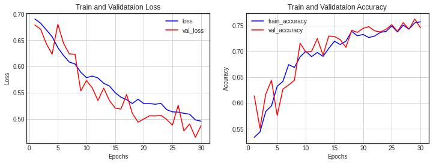

```python
history_dict = history.history
loss = history_dict['loss']
val_loss = history_dict['val_loss']
accuracy = history_dict['acc']
val_accuracy = history_dict['val_acc']

epochs = range(1, len(loss) + 1)

plt.figure(figsize = (12 , 4))

ax1 = plt.subplot(1, 2, 1)
ax1.plot(epochs, loss, color = 'blue', label = 'loss')
ax1.plot(epochs, val_loss, color = 'red', label = 'val_loss')
ax1.set_title('Train and Validataion Loss')
ax1.set_xlabel('Epochs')
ax1.set_ylabel('Loss')
ax1.grid()
ax1.legend()

ax2 = plt.subplot(1, 2, 2)
ax2.plot(epochs, accuracy, color = 'blue', label = 'train_accuracy')
ax2.plot(epochs, val_accuracy, color = 'red', label = 'val_accuracy')
ax2.set_title('Train and Validataion Accuracy')
ax2.set_xlabel('Epochs')
ax2.set_ylabel('Accuracy')
ax2.grid()
ax2.legend()
plt.show()
```

#### 모델 저장

```python
model.save("cats_and_dogs_model.h5")
```

### 사전 훈련된 모델 사용

```python
conv_base = VGG16(weights = 'imagenet',
                  input_shape = (150 ,150, 3), include_top = False)
```

```python
def build_model_with_pretrained(conv_base):
  model = Sequential()
  model.add(conv_base)
  model.add(Flatten())
  model.add(Dense(256, activation = 'relu'))
  model.add(Dense(1, activation = 'sigmoid'))

  model.compile(loss = 'binary_crossentropy',
                optimizer = RMSprop(2e-5),
                metrics = ['accuracy'])
  return model
```

파라미터의 수 확인!

```python
model = build_model_with_pretrained(conv_base)
model.summary()
```

```
Model: "sequential_4"
_________________________________________________________________
 Layer (type)                Output Shape              Param #
=================================================================
 vgg16 (Functional)          (None, 4, 4, 512)         14714688

 flatten_4 (Flatten)         (None, 8192)              0

 dense_8 (Dense)             (None, 256)               2097408

 dense_9 (Dense)             (None, 1)                 257

=================================================================
Total params: 16,812,353
Trainable params: 16,812,353
Non-trainable params: 0
_________________________________________________________________
```

#### 레이어 동결

- 훈련하기 전, 합성곱 기반 레이어들의 가중치 학습을 막기 위해 이를 동결

```python
print(len(model.trainable_weights))
```

```
30
```

```python
conv_base.trainable = False
print(len(model.trainable_weights))
```

```
4
```

#### 모델 컴파일

- trainable 속성을 변경했기 때문에 다시 모델을 컴파일 해야함

```python
model.compile(loss = 'binary_crossentropy',
               optimizer = Adam(2e-5),
               metrics = ['accuracy'])
```

#### 이미지 제너레이터

```python
train_datagen = ImageDataGenerator(
    rescale = 1./ 255,
    rotation_range = 40,
    width_shift_range = 0.2,
    height_shift_range = 0.2,
    shear_range = 0.2,
    zoom_range = 0.2,
    horizontal_flip = True
)

train_generator = train_datagen.flow_from_directory(
    train_dir,
    target_size = (150, 150),
    batch_size = 20,
    class_mode = 'binary'
)

val_datagen = ImageDataGenerator(rescale = 1/255)

validataion_generator = val_datagen.flow_from_directory(
    validation_dir,
    target_size = (150, 150),
    batch_size = 20,
    class_mode = 'binary'
)
```

```
Found 2000 images belonging to 2 classes.
Found 1000 images belonging to 2 classes.
```

#### 모델 재학습

```python
history2 = model.fit(train_generator,
                    steps_per_epoch = 100,
                    epochs = 30,
                    batch_size = 256,
                    validation_data = validataion_generator,
                    validation_steps = 50,
                    verbose = False)
```

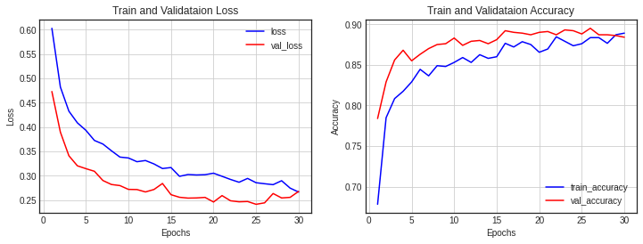

```python
history2_dict = history2.history
loss = history2_dict['loss']
val_loss = history2_dict['val_loss']
accuracy = history2_dict['accuracy']
val_accuracy = history2_dict['val_accuracy']

epochs = range(1, len(loss) + 1)

plt.figure(figsize = (12 , 4))

ax1 = plt.subplot(1, 2, 1)
ax1.plot(epochs, loss, color = 'blue', label = 'loss')
ax1.plot(epochs, val_loss, color = 'red', label = 'val_loss')
ax1.set_title('Train and Validataion Loss')
ax1.set_xlabel('Epochs')
ax1.set_ylabel('Loss')
ax1.grid()
ax1.legend()

ax2 = plt.subplot(1, 2, 2)
ax2.plot(epochs, accuracy, color = 'blue', label = 'train_accuracy')
ax2.plot(epochs, val_accuracy, color = 'red', label = 'val_accuracy')
ax2.set_title('Train and Validataion Accuracy')
ax2.set_xlabel('Epochs')
ax2.set_ylabel('Accuracy')
ax2.grid()
ax2.legend()
plt.show()
```

#### 모델 저장

```python
model.save("cats_and_dogs_with_pretrained_model.h5")
```

## Feature Map 시각화

```python
from tensorflow.keras.models import load_model
from tensorflow.keras.preprocessing import image
import numpy as np
```

### 모델 구성

```python
model = load_model('/content/cats_and_dogs_model.h5')
```

```python
img_path = '/content/cats_and_dogs_filtered/validation/dogs/dog.2000.jpg'

img = image.load_img(img_path, target_size = (150, 150))
img_tensor = image.img_to_array(img)
img_tensor = img_tensor[np.newaxis, ...]
img_tensor /= 255.
print(img_tensor.shape)
```

```
(1, 150, 150, 3)
```

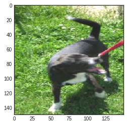

```python
plt.imshow(img_tensor[0])
plt.show()
```

```python
conv_output = [layer.output for layer in model.layers[:8]] # 각 층별 출력물
conv_output, model.summary()
```

```
Model: "sequential_2"
_________________________________________________________________
 Layer (type)                Output Shape              Param #
=================================================================
 conv2d_8 (Conv2D)           (None, 148, 148, 32)      896

 max_pooling2d_4 (MaxPooling  (None, 74, 74, 32)       0
 2D)

 conv2d_9 (Conv2D)           (None, 72, 72, 64)        18496

 max_pooling2d_5 (MaxPooling  (None, 36, 36, 64)       0
 2D)

 conv2d_10 (Conv2D)          (None, 34, 34, 128)       73856

 max_pooling2d_6 (MaxPooling  (None, 17, 17, 128)      0
 2D)

 conv2d_11 (Conv2D)          (None, 15, 15, 128)       147584

 max_pooling2d_7 (MaxPooling  (None, 7, 7, 128)        0
 2D)

 flatten_2 (Flatten)         (None, 6272)              0

 dropout_1 (Dropout)         (None, 6272)              0

 dense_4 (Dense)             (None, 512)               3211776

 dense_5 (Dense)             (None, 1)                 513

=================================================================
Total params: 3,453,121
Trainable params: 3,453,121
Non-trainable params: 0
_________________________________________________________________
```

```
([<KerasTensor: shape=(None, 148, 148, 32) dtype=float32 (created by layer 'conv2d_8')>,
  <KerasTensor: shape=(None, 74, 74, 32) dtype=float32 (created by layer 'max_pooling2d_4')>,
  <KerasTensor: shape=(None, 72, 72, 64) dtype=float32 (created by layer 'conv2d_9')>,
  <KerasTensor: shape=(None, 36, 36, 64) dtype=float32 (created by layer 'max_pooling2d_5')>,
  <KerasTensor: shape=(None, 34, 34, 128) dtype=float32 (created by layer 'conv2d_10')>,
  <KerasTensor: shape=(None, 17, 17, 128) dtype=float32 (created by layer 'max_pooling2d_6')>,
  <KerasTensor: shape=(None, 15, 15, 128) dtype=float32 (created by layer 'conv2d_11')>,
  <KerasTensor: shape=(None, 7, 7, 128) dtype=float32 (created by layer 'max_pooling2d_7')>],
 None)
```

```python
activation_model = Model(inputs = [model.input], outputs = conv_output)
# 모델의 입력물을 각 층마다 넣었을때
```

```python
activations = activation_model.predict(img_tensor)
```

```python
len(activations)
```

```
8
```

### 시각화

```
(1, 148, 148, 32)
```

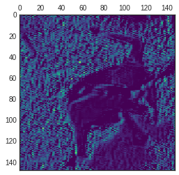

```python
print(activations[0].shape)
plt.matshow(activations[0][0, :, :, 7], cmap = 'viridis')
plt.show()
```

### 중간의 모든 활성화에 대해 시각화

```python
layer_names = []
for layer in model.layers[:8]:
  layer_names.append(layer.name)

images_per_row = 16

for layer_name, layer_activation in zip(layer_names, activations):
  num_features = layer_activation.shape[-1]

  size = layer_activation.shape[1]

  num_cols = num_features // images_per_row
  display_grid = np.zeros((size * num_cols, images_per_row * size))

  for col in range(num_cols):
    for row in range(images_per_row):
      channel_image = layer_activation[0, :, :, col * images_per_row * row]
      channel_image -= channel_image.mean()
      channel_image /= channel_image.std()
      channel_image -= 64
      channel_image -= 128
      channel_image = np.clip(channel_image, 0, 255).astype('uint8')
      display_grid[col * size: (col+1) * size, row * size : (row+1) * size] = channel_image

  scale = 1./size

  plt.figure(figsize = (scale * display_grid.shape[1].
                        scale * display_grid.shape[0]))
  plt.title(layer_name)
  plt.grid(False)
  plt.imshow(display_grid, aspect = 'auto', cmap = 'viridis')

plt.show()
```

[output not shown]